# Volunteer Summary

## Overall status

| Characteristic | Overall1 | Control1 | Treatment1 |
| --- | --- | --- | --- |
| time_point |  |  |  |
| 1st | 6 | 2 | 4 |
| 2nd | 4 | 2 | 2 |

1n

## Demographic information

| Characteristic | N | Overall, N = 6 | control, N = 2 | treatment, N = 4 | p-value |
| --- | --- | --- | --- | --- | --- |
| age | 6 | 52.53 ± 0.01 (53 - 53) | 52.53 ± 0.02 (53 - 53) | 52.52 ± 0.01 (53 - 53) | 0.631 |
| gender | 6 |  |  |  | >0.999 |
| female |  | 3 (50%) | 1 (50%) | 2 (50%) |  |
| male |  | 3 (50%) | 1 (50%) | 2 (50%) |  |
| occupation | 6 |  |  |  | 0.733 |
| manager |  | 1 (17%) | 0 (0%) | 1 (25%) |  |
| other |  | 1 (17%) | 1 (50%) | 0 (0%) |  |
| professional |  | 2 (33%) | 0 (0%) | 2 (50%) |  |
| unemploy |  | 2 (33%) | 1 (50%) | 1 (25%) |  |
| marital | 6 |  |  |  | 0.467 |
| divorced |  | 1 (17%) | 1 (50%) | 0 (0%) |  |
| married |  | 1 (17%) | 0 (0%) | 1 (25%) |  |
| other |  | 1 (17%) | 1 (50%) | 0 (0%) |  |
| separated |  | 2 (33%) | 0 (0%) | 2 (50%) |  |
| widowed |  | 1 (17%) | 0 (0%) | 1 (25%) |  |
| education | 6 |  |  |  | >0.999 |
| primary |  | 2 (33%) | 1 (50%) | 1 (25%) |  |
| secondary |  | 1 (17%) | 0 (0%) | 1 (25%) |  |
| university |  | 3 (50%) | 1 (50%) | 2 (50%) |  |
| family_income | 6 |  |  |  | >0.999 |
| 10001_20000 |  | 2 (33%) | 1 (50%) | 1 (25%) |  |
| 20001_30000 |  | 2 (33%) | 0 (0%) | 2 (50%) |  |
| 40000_above |  | 2 (33%) | 1 (50%) | 1 (25%) |  |
| religion | 6 |  |  |  | 0.733 |
| buddhism |  | 1 (17%) | 1 (50%) | 0 (0%) |  |
| catholic |  | 2 (33%) | 1 (50%) | 1 (25%) |  |
| christianity |  | 1 (17%) | 0 (0%) | 1 (25%) |  |
| taoism |  | 2 (33%) | 0 (0%) | 2 (50%) |  |
| source | 6 |  |  |  | >0.999 |
| bokss |  | 2 (33%) | 1 (50%) | 1 (25%) |  |
| instagram |  | 1 (17%) | 0 (0%) | 1 (25%) |  |
| refresh |  | 3 (50%) | 1 (50%) | 2 (50%) |  |

1Mean ± SD (Range); n (%)  
2Two Sample t-test; Fisher's exact test

## Measurement

| Characteristic | N | Overall, N = 6 | control, N = 2 | treatment, N = 4 | p-value |
| --- | --- | --- | --- | --- | --- |
| sets | 6 | 11.67 ± 2.88 (8 - 15) | 9.00 ± 1.41 (8 - 10) | 13.00 ± 2.45 (10 - 15) | 0.108 |
| ers_e | 6 | 35.00 ± 20.77 (8 - 54) | 27.50 ± 26.16 (9 - 46) | 38.75 ± 20.84 (8 - 54) | 0.591 |
| ers_r | 6 | 35.33 ± 20.99 (8 - 54) | 28.00 ± 28.28 (8 - 48) | 39.00 ± 20.35 (9 - 54) | 0.604 |
| who | 6 | 11.17 ± 3.71 (7 - 18) | 12.50 ± 7.78 (7 - 18) | 10.50 ± 1.00 (10 - 12) | 0.593 |
| phq | 6 | 14.33 ± 3.39 (9 - 18) | 16.00 ± 2.83 (14 - 18) | 13.50 ± 3.70 (9 - 18) | 0.456 |
| gad | 6 | 13.33 ± 4.41 (9 - 21) | 15.00 ± 8.49 (9 - 21) | 12.50 ± 2.38 (10 - 15) | 0.574 |
| pss_pa | 6 | 30.00 ± 6.45 (23 - 42) | 36.50 ± 7.78 (31 - 42) | 26.75 ± 2.63 (23 - 29) | 0.067 |
| pss_pa_r | 6 | 33.00 ± 6.45 (21 - 40) | 26.50 ± 7.78 (21 - 32) | 36.25 ± 2.63 (34 - 40) | 0.067 |
| pss_ps | 6 | 40.83 ± 5.49 (36 - 51) | 47.00 ± 5.66 (43 - 51) | 37.75 ± 1.26 (36 - 39) | 0.024 |
| pss | 6 | 73.83 ± 2.32 (72 - 78) | 73.50 ± 2.12 (72 - 75) | 74.00 ± 2.71 (72 - 78) | 0.834 |
| rki_responsible | 6 | 7.00 ± 10.86 (0 - 22) | 10.00 ± 14.14 (0 - 20) | 5.50 ± 11.00 (0 - 22) | 0.684 |
| rki_nonlinear | 6 | 6.67 ± 10.41 (0 - 22) | 11.00 ± 15.56 (0 - 22) | 4.50 ± 9.00 (0 - 18) | 0.533 |
| rki_peer | 6 | 5.33 ± 8.36 (0 - 18) | 9.00 ± 12.73 (0 - 18) | 3.50 ± 7.00 (0 - 14) | 0.510 |
| rki_expect | 6 | 1.83 ± 2.86 (0 - 6) | 2.50 ± 3.54 (0 - 5) | 1.50 ± 3.00 (0 - 6) | 0.732 |
| rki | 6 | 20.83 ± 32.31 (0 - 65) | 32.50 ± 45.96 (0 - 65) | 15.00 ± 30.00 (0 - 60) | 0.591 |
| raq_possible | 6 | 2.83 ± 4.40 (0 - 9) | 4.00 ± 5.66 (0 - 8) | 2.25 ± 4.50 (0 - 9) | 0.696 |
| raq_difficulty | 6 | 3.00 ± 4.65 (0 - 9) | 4.50 ± 6.36 (0 - 9) | 2.25 ± 4.50 (0 - 9) | 0.633 |
| raq | 6 | 5.83 ± 9.04 (0 - 18) | 8.50 ± 12.02 (0 - 17) | 4.50 ± 9.00 (0 - 18) | 0.663 |
| nb_pcs | 6 | 45.57 ± 4.28 (40 - 53) | 42.73 ± 3.48 (40 - 45) | 46.98 ± 4.30 (44 - 53) | 0.299 |
| nb_mcs | 6 | 38.31 ± 5.70 (28 - 44) | 38.35 ± 1.68 (37 - 40) | 38.29 ± 7.29 (28 - 44) | 0.992 |

1Mean ± SD (Range)  
2Two Sample t-test

## Data analysis

### Table

| Group | Characteristic | Beta | SE1 | 95% CI1 | p-value |
| --- | --- | --- | --- | --- | --- |
| sets | (Intercept) | 9.00 | 3.857 | 1.44, 16.6 |  |
|  | group |  |  |  |  |
|  | control | — | — | — |  |
|  | treatment | 4.00 | 4.724 | -5.26, 13.3 | 0.430 |
|  | time_point |  |  |  |  |
|  | 1st | — | — | — |  |
|  | 2nd | -3.50 | 5.454 | -14.2, 7.19 | 0.545 |
|  | group * time_point |  |  |  |  |
|  | treatment * 2nd | -2.50 | 7.215 | -16.6, 11.6 | 0.741 |
|  | Pseudo R square | 0.260 |  |  |  |
| ers_e | (Intercept) | 27.5 | 13.057 | 1.91, 53.1 |  |
|  | group |  |  |  |  |
|  | control | — | — | — |  |
|  | treatment | 11.2 | 15.991 | -20.1, 42.6 | 0.508 |
|  | time_point |  |  |  |  |
|  | 1st | — | — | — |  |
|  | 2nd | -24.5 | 18.465 | -60.7, 11.7 | 0.233 |
|  | group * time_point |  |  |  |  |
|  | treatment * 2nd | -9.75 | 24.427 | -57.6, 38.1 | 0.704 |
|  | Pseudo R square | 0.450 |  |  |  |
| ers_r | (Intercept) | 28.0 | 13.281 | 1.97, 54.0 |  |
|  | group |  |  |  |  |
|  | control | — | — | — |  |
|  | treatment | 11.0 | 16.265 | -20.9, 42.9 | 0.524 |
|  | time_point |  |  |  |  |
|  | 1st | — | — | — |  |
|  | 2nd | -23.0 | 18.782 | -59.8, 13.8 | 0.267 |
|  | group * time_point |  |  |  |  |
|  | treatment * 2nd | -12.5 | 24.846 | -61.2, 36.2 | 0.633 |
|  | Pseudo R square | 0.439 |  |  |  |

[output cut: 170 more lines]

1SE = Standard Error, CI = Confidence Interval

### Text

**sets**

We fitted a linear mixed model (estimated using REML and nloptwrap optimizer) to predict sets with group and time_point (formula: sets ~ 1 + group + time_point + group * time_point). The model included login_id as random effect (formula: ~1 | login_id). The model’s explanatory power related to the fixed effects alone (marginal R2) is 0.26. The model’s intercept, corresponding to group = control and time_point = 1st , is at 9.00 (S.E. = 3.86, p = 0.020, 95% CI [1.44, 16.56]). Within this model:

- The effect of group [treatment] is statistically non-significant and positive (beta = 4.00, S.E. = 4.72, p = 0.397, 95% CI [-5.26, 13.26]; Std. beta = 0.73, 95% CI [-0.96, 2.41])
- The effect of time point [2nd] is statistically non-significant and negative (beta = -3.50, S.E. = 5.45, p = 0.521, 95% CI [-14.19, 7.19]; Std. beta = -0.64, 95% CI [-2.58, 1.31])
- The interaction effect of time point [2nd] on group [treatment] is statistically non-significant and negative (beta = -2.50, S.E. = 7.22, p = 0.729, 95% CI [-16.64, 11.64]; Std. beta = -0.45, 95% CI [-3.02, 2.12])

Standardized parameters were obtained by fitting the model on a standardized version of the dataset. 95% Confidence Intervals (CIs) and p-values were computed using a Wald normal distribution approximation.

**ers_e**

We fitted a linear mixed model (estimated using REML and nloptwrap optimizer) to predict ers_e with group and time_point (formula: ers_e ~ 1 + group + time_point + group * time_point). The model included login_id as random effect (formula: ~1 | login_id). The model’s explanatory power related to the fixed effects alone (marginal R2) is 0.45. The model’s intercept, corresponding to group = control and time_point = 1st , is at 27.50 (S.E. = 13.06, p = 0.035, 95% CI [1.91, 53.09]). Within this model:

- The effect of group [treatment] is statistically non-significant and positive (beta = 11.25, S.E. = 15.99, p = 0.482, 95% CI [-20.09, 42.59]; Std. beta = 0.50, 95% CI [-0.89, 1.89])
- The effect of time point [2nd] is statistically non-significant and negative (beta = -24.50, S.E. = 18.47, p = 0.185, 95% CI [-60.69, 11.69]; Std. beta = -1.09, 95% CI [-2.70, 0.52])
- The interaction effect of time point [2nd] on group [treatment] is statistically non-significant and negative (beta = -9.75, S.E. = 24.43, p = 0.690, 95% CI [-57.63, 38.13]; Std. beta = -0.43, 95% CI [-2.56, 1.69])

Standardized parameters were obtained by fitting the model on a standardized version of the dataset. 95% Confidence Intervals (CIs) and p-values were computed using a Wald normal distribution approximation.

**ers_r**

We fitted a linear mixed model (estimated using REML and nloptwrap optimizer) to predict ers_r with group and time_point (formula: ers_r ~ 1 + group + time_point + group * time_point). The model included login_id as random effect (formula: ~1 | login_id). The model’s explanatory power related to the fixed effects alone (marginal R2) is 0.44. The model’s intercept, corresponding to group = control and time_point = 1st , is at 28.00 (S.E. = 13.28, p = 0.035, 95% CI [1.97, 54.03]). Within this model:

- The effect of group [treatment] is statistically non-significant and positive (beta = 11.00, S.E. = 16.27, p = 0.499, 95% CI [-20.88, 42.88]; Std. beta = 0.49, 95% CI [-0.92, 1.90])
- The effect of time point [2nd] is statistically non-significant and negative (beta = -23.00, S.E. = 18.78, p = 0.221, 95% CI [-59.81, 13.81]; Std. beta = -1.02, 95% CI [-2.65, 0.61])
- The interaction effect of time point [2nd] on group [treatment] is statistically non-significant and negative (beta = -12.50, S.E. = 24.85, p = 0.615, 95% CI [-61.20, 36.20]; Std. beta = -0.55, 95% CI [-2.71, 1.60])

Standardized parameters were obtained by fitting the model on a standardized version of the dataset. 95% Confidence Intervals (CIs) and p-values were computed using a Wald normal distribution approximation.

**who**

We fitted a linear mixed model (estimated using REML and nloptwrap optimizer) to predict who with group and time_point (formula: who ~ 1 + group + time_point + group * time_point). The model included login_id as random effect (formula: ~1 | login_id). The model’s total explanatory power is substantial (conditional R2 = 0.60) and the part related to the fixed effects alone (marginal R2) is of 0.41. The model’s intercept, corresponding to group = control and time_point = 1st , is at 12.50 (S.E. = 3.32, p < .001, 95% CI [5.99, 19.01]). Within this model:

- The effect of group [treatment] is statistically non-significant and negative (beta = -2.00, S.E. = 4.07, p = 0.623, 95% CI [-9.97, 5.97]; Std. beta = -0.36, 95% CI [-1.81, 1.08])
- The effect of time point [2nd] is statistically significant and negative (beta = -10.00, S.E. = 3.86, p = 0.010, 95% CI [-17.57, -2.43]; Std. beta = -1.81, 95% CI [-3.18, -0.44])
- The interaction effect of time point [2nd] on group [treatment] is statistically non-significant and positive (beta = 5.16, S.E. = 5.23, p = 0.323, 95% CI [-5.08, 15.40]; Std. beta = 0.94, 95% CI [-0.92, 2.79])

Standardized parameters were obtained by fitting the model on a standardized version of the dataset. 95% Confidence Intervals (CIs) and p-values were computed using a Wald normal distribution approximation.

**phq**

We fitted a linear mixed model (estimated using REML and nloptwrap optimizer) to predict phq with group and time_point (formula: phq ~ 1 + group + time_point + group * time_point). The model included login_id as random effect (formula: ~1 | login_id). The model’s explanatory power related to the fixed effects alone (marginal R2) is 0.35. The model’s intercept, corresponding to group = control and time_point = 1st , is at 16.00 (S.E. = 4.14, p < .001, 95% CI [7.89, 24.11]). Within this model:

- The effect of group [treatment] is statistically non-significant and negative (beta = -2.50, S.E. = 5.07, p = 0.622, 95% CI [-12.43, 7.43]; Std. beta = -0.39, 95% CI [-1.94, 1.16])
- The effect of time point [2nd] is statistically non-significant and negative (beta = -9.50, S.E. = 5.85, p = 0.105, 95% CI [-20.97, 1.97]; Std. beta = -1.48, 95% CI [-3.27, 0.31])
- The interaction effect of time point [2nd] on group [treatment] is statistically non-significant and positive (beta = 2.00, S.E. = 7.74, p = 0.796, 95% CI [-13.17, 17.17]; Std. beta = 0.31, 95% CI [-2.05, 2.68])

Standardized parameters were obtained by fitting the model on a standardized version of the dataset. 95% Confidence Intervals (CIs) and p-values were computed using a Wald normal distribution approximation.

**gad**

We fitted a linear mixed model (estimated using REML and nloptwrap optimizer) to predict gad with group and time_point (formula: gad ~ 1 + group + time_point + group * time_point). The model included login_id as random effect (formula: ~1 | login_id). The model’s explanatory power related to the fixed effects alone (marginal R2) is 0.31. The model’s intercept, corresponding to group = control and time_point = 1st , is at 15.00 (S.E. = 4.32, p < .001, 95% CI [6.54, 23.46]). Within this model:

- The effect of group [treatment] is statistically non-significant and negative (beta = -2.50, S.E. = 5.29, p = 0.636, 95% CI [-12.86, 7.86]; Std. beta = -0.39, 95% CI [-2.00, 1.22])
- The effect of time point [2nd] is statistically non-significant and negative (beta = -8.50, S.E. = 6.10, p = 0.164, 95% CI [-20.46, 3.46]; Std. beta = -1.32, 95% CI [-3.18, 0.54])
- The interaction effect of time point [2nd] on group [treatment] is statistically non-significant and positive (beta = 1.00, S.E. = 8.07, p = 0.901, 95% CI [-14.82, 16.82]; Std. beta = 0.16, 95% CI [-2.31, 2.62])

Standardized parameters were obtained by fitting the model on a standardized version of the dataset. 95% Confidence Intervals (CIs) and p-values were computed using a Wald normal distribution approximation.

**pss_pa**

We fitted a linear mixed model (estimated using REML and nloptwrap optimizer) to predict pss_pa with group and time_point (formula: pss_pa ~ 1 + group + time_point + group * time_point). The model included login_id as random effect (formula: ~1 | login_id). The model’s explanatory power related to the fixed effects alone (marginal R2) is 0.38. The model’s intercept, corresponding to group = control and time_point = 1st , is at 36.50 (S.E. = 8.45, p < .001, 95% CI [19.93, 53.07]). Within this model:

- The effect of group [treatment] is statistically non-significant and negative (beta = -9.75, S.E. = 10.35, p = 0.346, 95% CI [-30.04, 10.54]; Std. beta = -0.72, 95% CI [-2.23, 0.78])
- The effect of time point [2nd] is statistically significant and negative (beta = -25.00, S.E. = 11.96, p = 0.037, 95% CI [-48.43, -1.57]; Std. beta = -1.85, 95% CI [-3.59, -0.12])
- The interaction effect of time point [2nd] on group [treatment] is statistically non-significant and positive (beta = 14.25, S.E. = 15.82, p = 0.368, 95% CI [-16.75, 45.25]; Std. beta = 1.06, 95% CI [-1.24, 3.35])

Standardized parameters were obtained by fitting the model on a standardized version of the dataset. 95% Confidence Intervals (CIs) and p-values were computed using a Wald normal distribution approximation.

**pss_pa_r**

We fitted a linear mixed model (estimated using REML and nloptwrap optimizer) to predict pss_pa_r with group and time_point (formula: pss_pa_r ~ 1 + group + time_point + group * time_point). The model included login_id as random effect (formula: ~1 | login_id). The model’s total explanatory power is substantial (conditional R2 = 0.53) and the part related to the fixed effects alone (marginal R2) is of 0.27. The model’s intercept, corresponding to group = control and time_point = 1st , is at 26.50 (S.E. = 10.43, p = 0.011, 95% CI [6.06, 46.94]). Within this model:

- The effect of group [treatment] is statistically non-significant and positive (beta = 9.75, S.E. = 12.77, p = 0.445, 95% CI [-15.29, 34.79]; Std. beta = 0.64, 95% CI [-1.01, 2.30])
- The effect of time point [2nd] is statistically non-significant and negative (beta = -6.50, S.E. = 11.79, p = 0.582, 95% CI [-29.61, 16.61]; Std. beta = -0.43, 95% CI [-1.95, 1.10])
- The interaction effect of time point [2nd] on group [treatment] is statistically non-significant and negative (beta = -14.52, S.E. = 16.00, p = 0.364, 95% CI [-45.88, 16.83]; Std. beta = -0.96, 95% CI [-3.03, 1.11])

Standardized parameters were obtained by fitting the model on a standardized version of the dataset. 95% Confidence Intervals (CIs) and p-values were computed using a Wald normal distribution approximation.

**pss_ps**

We fitted a linear mixed model (estimated using REML and nloptwrap optimizer) to predict pss_ps with group and time_point (formula: pss_ps ~ 1 + group + time_point + group * time_point). The model included login_id as random effect (formula: ~1 | login_id). The model’s explanatory power related to the fixed effects alone (marginal R2) is 0.42. The model’s intercept, corresponding to group = control and time_point = 1st , is at 47.00 (S.E. = 10.42, p < .001, 95% CI [26.57, 67.43]). Within this model:

- The effect of group [treatment] is statistically non-significant and negative (beta = -9.25, S.E. = 12.76, p = 0.469, 95% CI [-34.27, 15.77]; Std. beta = -0.53, 95% CI [-1.98, 0.91])
- The effect of time point [2nd] is statistically significant and negative (beta = -30.50, S.E. = 14.74, p = 0.039, 95% CI [-59.39, -1.61]; Std. beta = -1.76, 95% CI [-3.43, -0.09])
- The interaction effect of time point [2nd] on group [treatment] is statistically non-significant and positive (beta = 11.75, S.E. = 19.50, p = 0.547, 95% CI [-26.46, 49.96]; Std. beta = 0.68, 95% CI [-1.53, 2.88])

Standardized parameters were obtained by fitting the model on a standardized version of the dataset. 95% Confidence Intervals (CIs) and p-values were computed using a Wald normal distribution approximation.

**pss**

We fitted a linear mixed model (estimated using REML and nloptwrap optimizer) to predict pss with group and time_point (formula: pss ~ 1 + group + time_point + group * time_point). The model included login_id as random effect (formula: ~1 | login_id). The model’s total explanatory power is substantial (conditional R2 = 0.38) and the part related to the fixed effects alone (marginal R2) is of 0.32. The model’s intercept, corresponding to group = control and time_point = 1st , is at 73.50 (S.E. = 20.53, p < .001, 95% CI [33.25, 113.75]). Within this model:

- The effect of group [treatment] is statistically non-significant and positive (beta = 0.50, S.E. = 25.15, p = 0.984, 95% CI [-48.79, 49.79]; Std. beta = 0.02, 95% CI [-1.58, 1.61])
- The effect of time point [2nd] is statistically non-significant and negative (beta = -37.00, S.E. = 27.80, p = 0.183, 95% CI [-91.48, 17.48]; Std. beta = -1.20, 95% CI [-2.96, 0.57])
- The interaction effect of time point [2nd] on group [treatment] is statistically non-significant and negative (beta = -2.63, S.E. = 36.99, p = 0.943, 95% CI [-75.12, 69.87]; Std. beta = -0.08, 95% CI [-2.43, 2.26])

Standardized parameters were obtained by fitting the model on a standardized version of the dataset. 95% Confidence Intervals (CIs) and p-values were computed using a Wald normal distribution approximation.

**rki_responsible**

We fitted a linear mixed model (estimated using REML and nloptwrap optimizer) to predict rki_responsible with group and time_point (formula: rki_responsible ~ 1 + group + time_point + group * time_point). The model included login_id as random effect (formula: ~1 | login_id). The model’s total explanatory power is substantial (conditional R2 = 0.96) and the part related to the fixed effects alone (marginal R2) is of 0.04. The model’s intercept, corresponding to group = control and time_point = 1st , is at 10.00 (S.E. = 9.31, p = 0.283, 95% CI [-8.25, 28.25]). Within this model:

- The effect of group [treatment] is statistically non-significant and negative (beta = -4.50, S.E. = 11.40, p = 0.693, 95% CI [-26.85, 17.85]; Std. beta = -0.36, 95% CI [-2.18, 1.45])
- The effect of time point [2nd] is statistically non-significant and positive (beta = 1.50, S.E. = 2.67, p = 0.575, 95% CI [-3.74, 6.74]; Std. beta = 0.12, 95% CI [-0.30, 0.55])
- The interaction effect of time point [2nd] on group [treatment] is statistically non-significant and positive (beta = 2.23, S.E. = 3.77, p = 0.555, 95% CI [-5.17, 9.62]; Std. beta = 0.18, 95% CI [-0.42, 0.78])

Standardized parameters were obtained by fitting the model on a standardized version of the dataset. 95% Confidence Intervals (CIs) and p-values were computed using a Wald normal distribution approximation.

**rki_nonlinear**

We fitted a linear mixed model (estimated using REML and nloptwrap optimizer) to predict rki_nonlinear with group and time_point (formula: rki_nonlinear ~ 1 + group + time_point + group * time_point). The model included login_id as random effect (formula: ~1 | login_id). The model’s total explanatory power is substantial (conditional R2 = 0.94) and the part related to the fixed effects alone (marginal R2) is of 0.06. The model’s intercept, corresponding to group = control and time_point = 1st , is at 11.00 (S.E. = 8.58, p = 0.200, 95% CI [-5.82, 27.82]). Within this model:

- The effect of group [treatment] is statistically non-significant and negative (beta = -6.50, S.E. = 10.51, p = 0.536, 95% CI [-27.11, 14.11]; Std. beta = -0.56, 95% CI [-2.34, 1.22])
- The effect of time point [2nd] is statistically non-significant and negative (beta = -0.50, S.E. = 3.16, p = 0.874, 95% CI [-6.70, 5.70]; Std. beta = -0.04, 95% CI [-0.58, 0.49])
- The interaction effect of time point [2nd] on group [treatment] is statistically non-significant and positive (beta = 5.31, S.E. = 4.45, p = 0.234, 95% CI [-3.42, 14.04]; Std. beta = 0.46, 95% CI [-0.30, 1.21])

Standardized parameters were obtained by fitting the model on a standardized version of the dataset. 95% Confidence Intervals (CIs) and p-values were computed using a Wald normal distribution approximation.

**rki_peer**

We fitted a linear mixed model (estimated using REML and nloptwrap optimizer) to predict rki_peer with group and time_point (formula: rki_peer ~ 1 + group + time_point + group * time_point). The model included login_id as random effect (formula: ~1 | login_id). The model’s total explanatory power is substantial (conditional R2 = 0.95) and the part related to the fixed effects alone (marginal R2) is of 0.15. The model’s intercept, corresponding to group = control and time_point = 1st , is at 9.00 (S.E. = 6.03, p = 0.136, 95% CI [-2.82, 20.82]). Within this model:

- The effect of group [treatment] is statistically non-significant and negative (beta = -5.50, S.E. = 7.39, p = 0.457, 95% CI [-19.98, 8.98]; Std. beta = -0.68, 95% CI [-2.45, 1.10])
- The effect of time point [2nd] is statistically non-significant and positive (beta = 0.50, S.E. = 2.13, p = 0.814, 95% CI [-3.67, 4.67]; Std. beta = 0.06, 95% CI [-0.45, 0.57])
- The interaction effect of time point [2nd] on group [treatment] is statistically non-significant and negative (beta = -3.28, S.E. = 3.00, p = 0.274, 95% CI [-9.16, 2.60]; Std. beta = -0.40, 95% CI [-1.12, 0.32])

Standardized parameters were obtained by fitting the model on a standardized version of the dataset. 95% Confidence Intervals (CIs) and p-values were computed using a Wald normal distribution approximation.

**rki_expect**

We fitted a linear mixed model (estimated using REML and nloptwrap optimizer) to predict rki_expect with group and time_point (formula: rki_expect ~ 1 + group + time_point + group * time_point). The model included login_id as random effect (formula: ~1 | login_id). The model’s total explanatory power is substantial (conditional R2 = 0.99) and the part related to the fixed effects alone (marginal R2) is of 0.04. The model’s intercept, corresponding to group = control and time_point = 1st , is at 2.50 (S.E. = 2.30, p = 0.277, 95% CI [-2.01, 7.01]). Within this model:

- The effect of group [treatment] is statistically non-significant and negative (beta = -1.00, S.E. = 2.82, p = 0.723, 95% CI [-6.53, 4.53]; Std. beta = -0.34, 95% CI [-2.19, 1.52])
- The effect of time point [2nd] is statistically non-significant and positive (beta = 0.50, S.E. = 0.35, p = 0.157, 95% CI [-0.19, 1.19]; Std. beta = 0.17, 95% CI [-0.06, 0.40])
- The interaction effect of time point [2nd] on group [treatment] is statistically non-significant and negative (beta = -0.48, S.E. = 0.50, p = 0.334, 95% CI [-1.46, 0.50]; Std. beta = -0.16, 95% CI [-0.49, 0.17])

Standardized parameters were obtained by fitting the model on a standardized version of the dataset. 95% Confidence Intervals (CIs) and p-values were computed using a Wald normal distribution approximation.

**rki**

We fitted a linear mixed model (estimated using REML and nloptwrap optimizer) to predict rki with group and time_point (formula: rki ~ 1 + group + time_point + group * time_point). The model included login_id as random effect (formula: ~1 | login_id). The model’s total explanatory power is substantial (conditional R2 = 0.99) and the part related to the fixed effects alone (marginal R2) is of 0.06. The model’s intercept, corresponding to group = control and time_point = 1st , is at 32.50 (S.E. = 25.72, p = 0.206, 95% CI [-17.90, 82.90]). Within this model:

- The effect of group [treatment] is statistically non-significant and negative (beta = -17.50, S.E. = 31.50, p = 0.578, 95% CI [-79.23, 44.23]; Std. beta = -0.51, 95% CI [-2.32, 1.29])
- The effect of time point [2nd] is statistically non-significant and positive (beta = 2.00, S.E. = 3.80, p = 0.599, 95% CI [-5.45, 9.45]; Std. beta = 0.06, 95% CI [-0.16, 0.28])
- The interaction effect of time point [2nd] on group [treatment] is statistically non-significant and positive (beta = 3.16, S.E. = 5.37, p = 0.556, 95% CI [-7.36, 13.69]; Std. beta = 0.09, 95% CI [-0.22, 0.40])

Standardized parameters were obtained by fitting the model on a standardized version of the dataset. 95% Confidence Intervals (CIs) and p-values were computed using a Wald normal distribution approximation.

**raq_possible**

We fitted a linear mixed model (estimated using REML and nloptwrap optimizer) to predict raq_possible with group and time_point (formula: raq_possible ~ 1 + group + time_point + group * time_point). The model included login_id as random effect (formula: ~1 | login_id). The model’s total explanatory power is substantial (conditional R2 = 0.88) and the part related to the fixed effects alone (marginal R2) is of 0.07. The model’s intercept, corresponding to group = control and time_point = 1st , is at 4.00 (S.E. = 4.30, p = 0.352, 95% CI [-4.42, 12.42]). Within this model:

- The effect of group [treatment] is statistically non-significant and negative (beta = -1.75, S.E. = 5.26, p = 0.739, 95% CI [-12.06, 8.56]; Std. beta = -0.30, 95% CI [-2.10, 1.49])
- The effect of time point [2nd] is statistically non-significant and positive (beta = 2.50, S.E. = 2.21, p = 0.258, 95% CI [-1.83, 6.83]; Std. beta = 0.43, 95% CI [-0.32, 1.19])
- The interaction effect of time point [2nd] on group [treatment] is statistically non-significant and negative (beta = -0.20, S.E. = 3.10, p = 0.948, 95% CI [-6.28, 5.88]; Std. beta = -0.04, 95% CI [-1.09, 1.02])

Standardized parameters were obtained by fitting the model on a standardized version of the dataset. 95% Confidence Intervals (CIs) and p-values were computed using a Wald normal distribution approximation.

**raq_difficulty**

We fitted a linear mixed model (estimated using REML and nloptwrap optimizer) to predict raq_difficulty with group and time_point (formula: raq_difficulty ~ 1 + group + time_point + group * time_point). The model included login_id as random effect (formula: ~1 | login_id). The model’s total explanatory power is substantial (conditional R2 = 0.98) and the part related to the fixed effects alone (marginal R2) is of 0.07. The model’s intercept, corresponding to group = control and time_point = 1st , is at 4.50 (S.E. = 3.74, p = 0.229, 95% CI [-2.83, 11.83]). Within this model:

- The effect of group [treatment] is statistically non-significant and negative (beta = -2.25, S.E. = 4.58, p = 0.623, 95% CI [-11.23, 6.73]; Std. beta = -0.46, 95% CI [-2.27, 1.36])
- The effect of time point [2nd] is statistically non-significant and positive (beta = 1.00, S.E. = 0.71, p = 0.156, 95% CI [-0.38, 2.38]; Std. beta = 0.20, 95% CI [-0.08, 0.48])
- The interaction effect of time point [2nd] on group [treatment] is statistically non-significant and negative (beta = -0.96, S.E. = 1.00, p = 0.335, 95% CI [-2.91, 0.99]; Std. beta = -0.19, 95% CI [-0.59, 0.20])

Standardized parameters were obtained by fitting the model on a standardized version of the dataset. 95% Confidence Intervals (CIs) and p-values were computed using a Wald normal distribution approximation.

**raq**

We fitted a linear mixed model (estimated using REML and nloptwrap optimizer) to predict raq with group and time_point (formula: raq ~ 1 + group + time_point + group * time_point). The model included login_id as random effect (formula: ~1 | login_id). The model’s total explanatory power is substantial (conditional R2 = 0.94) and the part related to the fixed effects alone (marginal R2) is of 0.06. The model’s intercept, corresponding to group = control and time_point = 1st , is at 8.50 (S.E. = 7.98, p = 0.287, 95% CI [-7.15, 24.15]). Within this model:

- The effect of group [treatment] is statistically non-significant and negative (beta = -4.00, S.E. = 9.78, p = 0.682, 95% CI [-23.16, 15.16]; Std. beta = -0.38, 95% CI [-2.18, 1.43])
- The effect of time point [2nd] is statistically non-significant and positive (beta = 3.50, S.E. = 2.82, p = 0.215, 95% CI [-2.03, 9.03]; Std. beta = 0.33, 95% CI [-0.19, 0.85])
- The interaction effect of time point [2nd] on group [treatment] is statistically non-significant and negative (beta = -1.22, S.E. = 3.97, p = 0.759, 95% CI [-9.01, 6.57]; Std. beta = -0.11, 95% CI [-0.85, 0.62])

Standardized parameters were obtained by fitting the model on a standardized version of the dataset. 95% Confidence Intervals (CIs) and p-values were computed using a Wald normal distribution approximation.

**nb_pcs**

We fitted a linear mixed model (estimated using REML and nloptwrap optimizer) to predict nb_pcs with group and time_point (formula: nb_pcs ~ 1 + group + time_point + group * time_point). The model included login_id as random effect (formula: ~1 | login_id). The model’s total explanatory power is substantial (conditional R2 = 0.42) and the part related to the fixed effects alone (marginal R2) is of 0.28. The model’s intercept, corresponding to group = control and time_point = 1st , is at 42.73 (S.E. = 4.28, p < .001, 95% CI [34.34, 51.13]). Within this model:

- The effect of group [treatment] is statistically non-significant and positive (beta = 4.25, S.E. = 5.24, p = 0.418, 95% CI [-6.03, 14.53]; Std. beta = 0.68, 95% CI [-0.96, 2.31])
- The effect of time point [2nd] is statistically non-significant and negative (beta = -2.70, S.E. = 5.45, p = 0.621, 95% CI [-13.38, 7.99]; Std. beta = -0.43, 95% CI [-2.13, 1.27])
- The interaction effect of time point [2nd] on group [treatment] is statistically non-significant and negative (beta = -6.15, S.E. = 7.31, p = 0.400, 95% CI [-20.47, 8.17]; Std. beta = -0.98, 95% CI [-3.26, 1.30])

Standardized parameters were obtained by fitting the model on a standardized version of the dataset. 95% Confidence Intervals (CIs) and p-values were computed using a Wald normal distribution approximation.

**nb_mcs**

We fitted a linear mixed model (estimated using REML and nloptwrap optimizer) to predict nb_mcs with group and time_point (formula: nb_mcs ~ 1 + group + time_point + group * time_point). The model included login_id as random effect (formula: ~1 | login_id). The model’s explanatory power related to the fixed effects alone (marginal R2) is 0.38. The model’s intercept, corresponding to group = control and time_point = 1st , is at 38.35 (S.E. = 5.20, p < .001, 95% CI [28.16, 48.54]). Within this model:

- The effect of group [treatment] is statistically non-significant and negative (beta = -0.06, S.E. = 6.37, p = 0.992, 95% CI [-12.54, 12.42]; Std. beta = -7.37e-03, 95% CI [-1.51, 1.50])
- The effect of time point [2nd] is statistically non-significant and positive (beta = 2.08, S.E. = 7.35, p = 0.778, 95% CI [-12.33, 16.48]; Std. beta = 0.25, 95% CI [-1.49, 1.99])
- The interaction effect of time point [2nd] on group [treatment] is statistically non-significant and positive (beta = 11.87, S.E. = 9.72, p = 0.222, 95% CI [-7.18, 30.93]; Std. beta = 1.43, 95% CI [-0.87, 3.73])

Standardized parameters were obtained by fitting the model on a standardized version of the dataset. 95% Confidence Intervals (CIs) and p-values were computed using a Wald normal distribution approximation.

## Likelihood ratio tests

| outcome | model | npar | AIC | BIC | logLik | deviance | Chisq | Df | p |
| --- | --- | --- | --- | --- | --- | --- | --- | --- | --- |
| sets | null | 3 | 67.429 | 68.337 | -30.715 | 61.429 |  |  |  |
| sets | random | 6 | 69.199 | 71.014 | -28.599 | 57.199 | 4.231 | 3 | 0.238 |
| ers_e | null | 3 | 95.605 | 96.513 | -44.802 | 89.605 |  |  |  |
| ers_e | random | 6 | 93.588 | 95.404 | -40.794 | 81.588 | 8.017 | 3 | 0.046 |
| ers_r | null | 3 | 95.689 | 96.596 | -44.844 | 89.689 |  |  |  |
| ers_r | random | 6 | 93.928 | 95.744 | -40.964 | 81.928 | 7.761 | 3 | 0.051 |
| who | null | 3 | 67.488 | 68.396 | -30.744 | 61.488 |  |  |  |
| who | random | 6 | 65.748 | 67.564 | -26.874 | 53.748 | 7.740 | 3 | 0.052 |
| phq | null | 3 | 70.512 | 71.420 | -32.256 | 64.512 |  |  |  |
| phq | random | 6 | 70.607 | 72.423 | -29.304 | 58.607 | 5.905 | 3 | 0.116 |
| gad | null | 3 | 70.545 | 71.452 | -32.272 | 64.545 |  |  |  |
| gad | random | 6 | 71.447 | 73.263 | -29.724 | 59.447 | 5.098 | 3 | 0.165 |
| pss_pa | null | 3 | 85.368 | 86.276 | -39.684 | 79.368 |  |  |  |
| pss_pa | random | 6 | 84.896 | 86.712 | -36.448 | 72.896 | 6.472 | 3 | 0.091 |
| pss_pa_r | null | 3 | 87.655 | 88.563 | -40.828 | 81.655 |  |  |  |
| pss_pa_r | random | 6 | 88.528 | 90.344 | -38.264 | 76.528 | 5.127 | 3 | 0.163 |
| pss_ps | null | 3 | 90.372 | 91.280 | -42.186 | 84.372 |  |  |  |
| pss_ps | random | 6 | 89.079 | 90.895 | -38.540 | 77.079 | 7.293 | 3 | 0.063 |
| pss | null | 3 | 101.951 | 102.859 | -47.976 | 95.951 |  |  |  |
| pss | random | 6 | 102.615 | 104.430 | -45.307 | 90.615 | 5.336 | 3 | 0.149 |
| rki_responsible | null | 3 | 74.029 | 74.937 | -34.014 | 68.029 |  |  |  |
| rki_responsible | random | 6 | 76.675 | 78.491 | -32.338 | 64.675 | 3.354 | 3 | 0.340 |
| rki_nonlinear | null | 3 | 74.580 | 75.488 | -34.290 | 68.580 |  |  |  |
| rki_nonlinear | random | 6 | 76.992 | 78.807 | -32.496 | 64.992 | 3.588 | 3 | 0.310 |
| rki_peer | null | 3 | 67.149 | 68.057 | -30.575 | 61.149 |  |  |  |
| rki_peer | random | 6 | 69.600 | 71.415 | -28.800 | 57.600 | 3.550 | 3 | 0.314 |
| rki_expect | null | 3 | 40.825 | 41.733 | -17.412 | 34.825 |  |  |  |
| rki_expect | random | 6 | 43.757 | 45.573 | -15.879 | 31.757 | 3.067 | 3 | 0.381 |
| rki | null | 3 | 89.109 | 90.017 | -41.554 | 83.109 |  |  |  |
| rki | random | 6 | 91.733 | 93.548 | -39.866 | 79.733 | 3.376 | 3 | 0.337 |
| raq_possible | null | 3 | 63.263 | 64.171 | -28.631 | 57.263 |  |  |  |
| raq_possible | random | 6 | 65.697 | 67.512 | -26.848 | 53.697 | 3.566 | 3 | 0.312 |
| raq_difficulty | null | 3 | 52.407 | 53.315 | -23.204 | 46.407 |  |  |  |
| raq_difficulty | random | 6 | 55.105 | 56.921 | -21.553 | 43.105 | 3.302 | 3 | 0.347 |
| raq | null | 3 | 72.650 | 73.557 | -33.325 | 66.650 |  |  |  |
| raq | random | 6 | 75.213 | 77.029 | -31.607 | 63.213 | 3.436 | 3 | 0.329 |
| nb_pcs | null | 3 | 70.067 | 70.975 | -32.034 | 64.067 |  |  |  |
| nb_pcs | random | 6 | 71.139 | 72.954 | -29.569 | 59.139 | 4.928 | 3 | 0.177 |
| nb_mcs | null | 3 | 75.621 | 76.529 | -34.811 | 69.621 |  |  |  |
| nb_mcs | random | 6 | 75.166 | 76.982 | -31.583 | 63.166 | 6.455 | 3 | 0.091 |

## Post hoc analysis text

### Table

[output not shown]

### Between group

**sets**

*1st*

t(6.00) = 0.85, p = 0.430, Cohen d = -0.73, 95% CI (-7.56 to 15.56)

*2st*

t(6.00) = 0.25, p = 0.814, Cohen d = -0.28, 95% CI (-13.42 to 16.42)

**ers_e**

*1st*

t(6.00) = 0.70, p = 0.508, Cohen d = -0.61, 95% CI (-27.88 to 50.38)

*2st*

t(6.00) = 0.07, p = 0.944, Cohen d = -0.08, 95% CI (-49.02 to 52.02)

**ers_r**

*1st*

t(6.00) = 0.68, p = 0.524, Cohen d = -0.59, 95% CI (-28.80 to 50.80)

*2st*

t(6.00) = -0.07, p = 0.945, Cohen d = 0.08, 95% CI (-52.88 to 49.88)

**who**

*1st*

t(5.62) = -0.49, p = 0.641, Cohen d = 0.52, 95% CI (-12.11 to 8.11)

*2st*

t(5.96) = 0.62, p = 0.556, Cohen d = -0.82, 95% CI (-9.27 to 15.59)

**phq**

*1st*

t(6.00) = -0.49, p = 0.639, Cohen d = 0.43, 95% CI (-14.90 to 9.90)

*2st*

t(6.00) = -0.08, p = 0.942, Cohen d = 0.09, 95% CI (-16.51 to 15.51)

**gad**

*1st*

t(6.00) = -0.47, p = 0.653, Cohen d = 0.41, 95% CI (-15.43 to 10.43)

*2st*

t(6.00) = -0.22, p = 0.833, Cohen d = 0.25, 95% CI (-18.20 to 15.20)

**pss_pa**

*1st*

t(6.00) = -0.94, p = 0.383, Cohen d = 0.82, 95% CI (-35.09 to 15.59)

*2st*

t(6.00) = 0.34, p = 0.748, Cohen d = -0.38, 95% CI (-28.21 to 37.21)

**pss_pa_r**

*1st*

t(5.54) = 0.76, p = 0.477, Cohen d = -0.83, 95% CI (-22.15 to 41.65)

*2st*

t(5.95) = -0.30, p = 0.773, Cohen d = 0.40, 95% CI (-43.54 to 34.00)

**pss_ps**

*1st*

t(6.00) = -0.72, p = 0.496, Cohen d = 0.63, 95% CI (-40.48 to 21.98)

*2st*

t(6.00) = 0.15, p = 0.884, Cohen d = -0.17, 95% CI (-37.82 to 42.82)

**pss**

*1st*

t(5.97) = 0.02, p = 0.985, Cohen d = -0.02, 95% CI (-61.11 to 62.11)

*2st*

t(6.00) = -0.07, p = 0.950, Cohen d = 0.08, 95% CI (-81.39 to 77.14)

**rki_responsible**

*1st*

t(4.08) = -0.39, p = 0.713, Cohen d = 1.68, 95% CI (-35.91 to 26.91)

*2st*

t(4.29) = -0.20, p = 0.853, Cohen d = 0.85, 95% CI (-33.54 to 29.00)

**rki_nonlinear**

*1st*

t(4.14) = -0.62, p = 0.569, Cohen d = 2.06, 95% CI (-35.30 to 22.30)

*2st*

t(4.47) = -0.11, p = 0.916, Cohen d = 0.38, 95% CI (-29.89 to 27.50)

**rki_peer**

*1st*

t(4.13) = -0.74, p = 0.497, Cohen d = 2.58, 95% CI (-25.76 to 14.76)

*2st*

t(4.43) = -1.16, p = 0.303, Cohen d = 4.13, 95% CI (-28.96 to 11.40)

**rki_expect**

*1st*

t(4.02) = -0.35, p = 0.741, Cohen d = 2.83, 95% CI (-8.81 to 6.81)

*2st*

t(4.09) = -0.52, p = 0.628, Cohen d = 4.20, 95% CI (-9.28 to 6.31)

**rki**

*1st*

t(4.02) = -0.56, p = 0.608, Cohen d = 4.60, 95% CI (-104.76 to 69.76)

*2st*

t(4.08) = -0.45, p = 0.673, Cohen d = 3.77, 95% CI (-101.43 to 72.76)

**raq_possible**

*1st*

t(4.28) = -0.33, p = 0.755, Cohen d = 0.79, 95% CI (-15.99 to 12.49)

*2st*

t(4.84) = -0.35, p = 0.738, Cohen d = 0.88, 95% CI (-16.27 to 12.36)

**raq_difficulty**

*1st*

t(4.04) = -0.49, p = 0.649, Cohen d = 3.19, 95% CI (-14.92 to 10.42)

*2st*

t(4.13) = -0.70, p = 0.523, Cohen d = 4.55, 95% CI (-15.85 to 9.43)

**raq**

*1st*

t(4.13) = -0.41, p = 0.703, Cohen d = 1.42, 95% CI (-30.81 to 22.81)

*2st*

t(4.43) = -0.52, p = 0.626, Cohen d = 1.85, 95% CI (-31.92 to 21.48)

**nb_pcs**

*1st*

t(5.86) = 0.81, p = 0.450, Cohen d = -0.78, 95% CI (-8.66 to 17.15)

*2st*

t(5.99) = -0.28, p = 0.785, Cohen d = 0.35, 95% CI (-18.28 to 14.47)

**nb_mcs**

*1st*

t(6.00) = -0.01, p = 0.993, Cohen d = 0.01, 95% CI (-15.64 to 15.52)

*2st*

t(6.00) = 1.44, p = 0.201, Cohen d = -1.61, 95% CI (-8.30 to 31.92)

### Within treatment group

**sets**

*1st vs 2st*

t(3.60) = -1.10, p = 0.339, Cohen d = 1.10, 95% CI (-21.83 to 9.83)

**ers_e**

*1st vs 2st*

t(3.60) = -1.85, p = 0.145, Cohen d = 1.85, 95% CI (-87.84 to 19.34)

**ers_r**

*1st vs 2st*

t(3.60) = -1.89, p = 0.140, Cohen d = 1.89, 95% CI (-90.01 to 19.01)

**who**

*1st vs 2st*

t(2.97) = -1.19, p = 0.322, Cohen d = 1.25, 95% CI (-17.90 to 8.22)

**phq**

*1st vs 2st*

t(3.60) = -1.28, p = 0.276, Cohen d = 1.28, 95% CI (-24.49 to 9.49)

**gad**

*1st vs 2st*

t(3.60) = -1.23, p = 0.293, Cohen d = 1.23, 95% CI (-25.21 to 10.21)

**pss_pa**

*1st vs 2st*

t(3.60) = -0.90, p = 0.425, Cohen d = 0.90, 95% CI (-45.45 to 23.95)

**pss_pa_r**

*1st vs 2st*

t(2.90) = -1.68, p = 0.194, Cohen d = 1.78, 95% CI (-61.57 to 19.53)

**pss_ps**

*1st vs 2st*

t(3.60) = -1.27, p = 0.279, Cohen d = 1.27, 95% CI (-61.53 to 24.03)

**pss**

*1st vs 2st*

t(3.44) = -1.40, p = 0.245, Cohen d = 1.43, 95% CI (-123.66 to 44.41)

**rki_responsible**

*1st vs 2st*

t(2.04) = 1.38, p = 0.299, Cohen d = -1.39, 95% CI (-7.67 to 15.12)

**rki_nonlinear**

*1st vs 2st*

t(2.07) = 1.50, p = 0.269, Cohen d = -1.52, 95% CI (-8.58 to 18.19)

**rki_peer**

*1st vs 2st*

t(2.06) = -1.29, p = 0.323, Cohen d = 1.31, 95% CI (-11.80 to 6.24)

**rki_expect**

*1st vs 2st*

t(2.01) = 0.05, p = 0.965, Cohen d = -0.05, 95% CI (-1.50 to 1.53)

**rki**

*1st vs 2st*

t(2.01) = 1.35, p = 0.308, Cohen d = -1.36, 95% CI (-11.15 to 21.48)

**raq_possible**

*1st vs 2st*

t(2.14) = 1.01, p = 0.413, Cohen d = -1.04, 95% CI (-6.89 to 11.49)

**raq_difficulty**

*1st vs 2st*

t(2.02) = 0.06, p = 0.960, Cohen d = -0.06, 95% CI (-2.98 to 3.06)

**raq**

*1st vs 2st*

t(2.06) = 0.80, p = 0.507, Cohen d = -0.81, 95% CI (-9.67 to 14.23)

**nb_pcs**

*1st vs 2st*

t(3.23) = -1.56, p = 0.210, Cohen d = 1.62, 95% CI (-26.18 to 8.49)

**nb_mcs**

*1st vs 2st*

t(3.60) = 1.90, p = 0.138, Cohen d = -1.90, 95% CI (-7.39 to 35.28)

### Within control group

**sets**

*1st vs 2st*

t(2.40) = -0.64, p = 0.577, Cohen d = 0.64, 95% CI (-23.59 to 16.59)

**ers_e**

*1st vs 2st*

t(2.40) = -1.33, p = 0.297, Cohen d = 1.33, 95% CI (-92.52 to 43.52)

**ers_r**

*1st vs 2st*

t(2.40) = -1.22, p = 0.327, Cohen d = 1.22, 95% CI (-92.18 to 46.18)

**who**

*1st vs 2st*

t(2.16) = -2.59, p = 0.113, Cohen d = 2.59, 95% CI (-25.50 to 5.50)

**phq**

*1st vs 2st*

t(2.40) = -1.62, p = 0.225, Cohen d = 1.62, 95% CI (-31.06 to 12.06)

**gad**

*1st vs 2st*

t(2.40) = -1.39, p = 0.279, Cohen d = 1.39, 95% CI (-30.98 to 13.98)

**pss_pa**

*1st vs 2st*

t(2.40) = -2.09, p = 0.150, Cohen d = 2.09, 95% CI (-69.04 to 19.04)

**pss_pa_r**

*1st vs 2st*

t(2.14) = -0.55, p = 0.634, Cohen d = 0.55, 95% CI (-54.20 to 41.20)

**pss_ps**

*1st vs 2st*

t(2.40) = -2.07, p = 0.153, Cohen d = 2.07, 95% CI (-84.79 to 23.79)

**pss**

*1st vs 2st*

t(2.32) = -1.33, p = 0.299, Cohen d = 1.33, 95% CI (-141.94 to 67.94)

**rki_responsible**

*1st vs 2st*

t(2.00) = 0.56, p = 0.631, Cohen d = -0.56, 95% CI (-10.01 to 13.01)

**rki_nonlinear**

*1st vs 2st*

t(2.00) = -0.16, p = 0.889, Cohen d = 0.16, 95% CI (-14.10 to 13.10)

**rki_peer**

*1st vs 2st*

t(2.00) = 0.23, p = 0.836, Cohen d = -0.23, 95% CI (-8.65 to 9.65)

**rki_expect**

*1st vs 2st*

t(2.00) = 1.42, p = 0.292, Cohen d = -1.42, 95% CI (-1.02 to 2.02)

**rki**

*1st vs 2st*

t(2.00) = 0.53, p = 0.651, Cohen d = -0.53, 95% CI (-14.35 to 18.35)

**raq_possible**

*1st vs 2st*

t(2.00) = 1.13, p = 0.375, Cohen d = -1.13, 95% CI (-6.99 to 11.99)

**raq_difficulty**

*1st vs 2st*

t(2.00) = 1.42, p = 0.292, Cohen d = -1.42, 95% CI (-2.03 to 4.03)

**raq**

*1st vs 2st*

t(2.00) = 1.24, p = 0.340, Cohen d = -1.24, 95% CI (-8.63 to 15.63)

**nb_pcs**

*1st vs 2st*

t(2.24) = -0.49, p = 0.665, Cohen d = 0.49, 95% CI (-23.88 to 18.49)

**nb_mcs**

*1st vs 2st*

t(2.40) = 0.28, p = 0.800, Cohen d = -0.28, 95% CI (-25.00 to 29.15)

### Plot

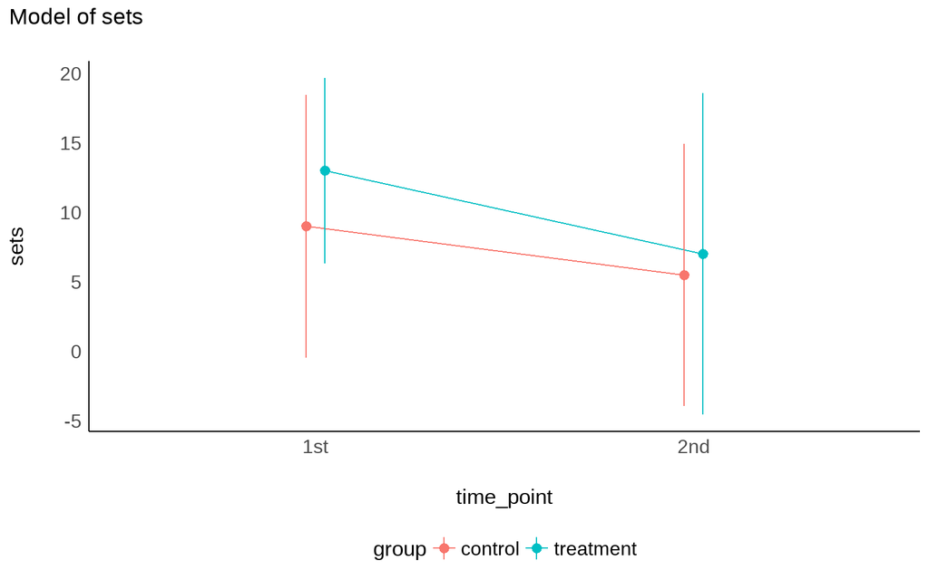

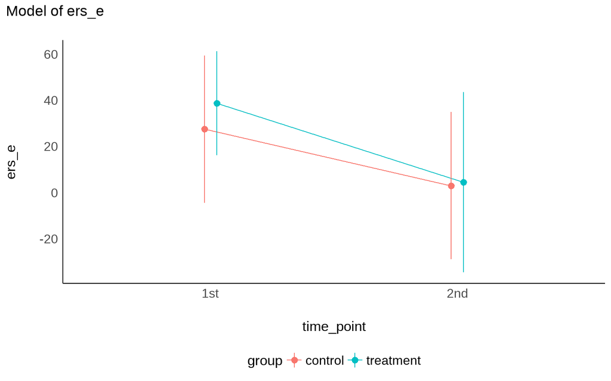

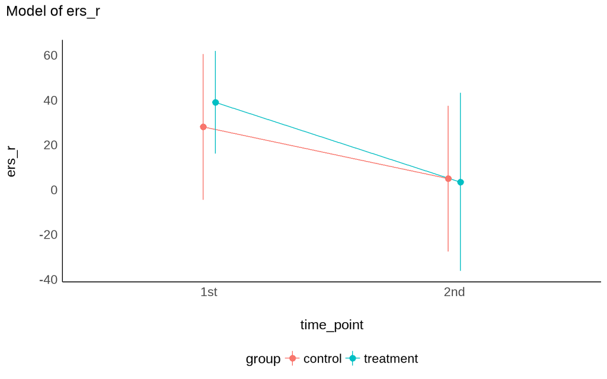

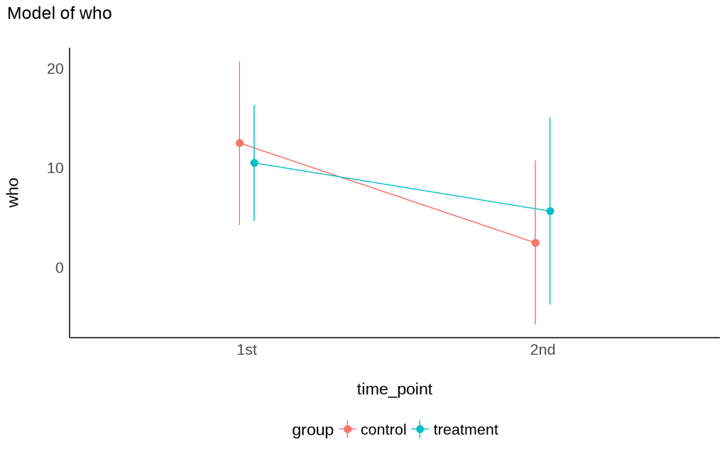

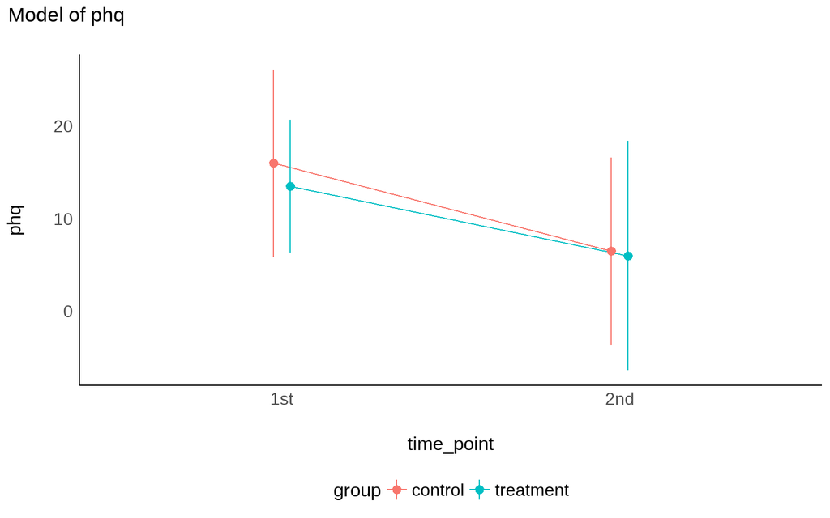

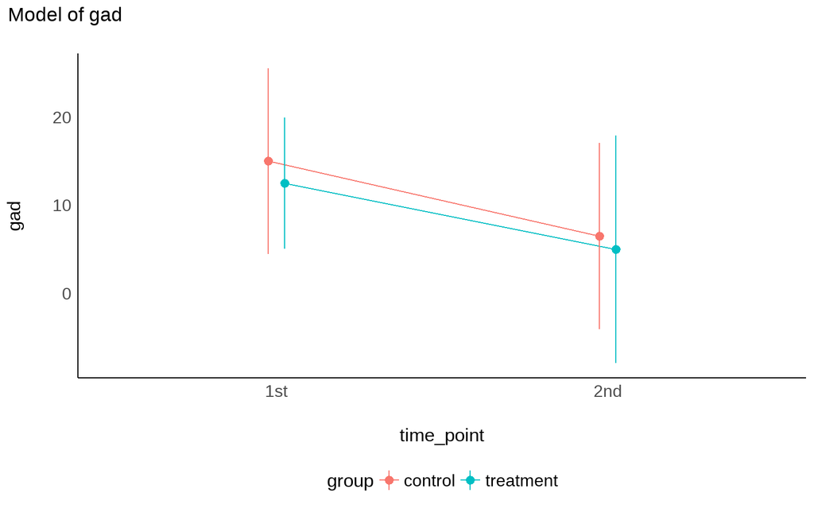

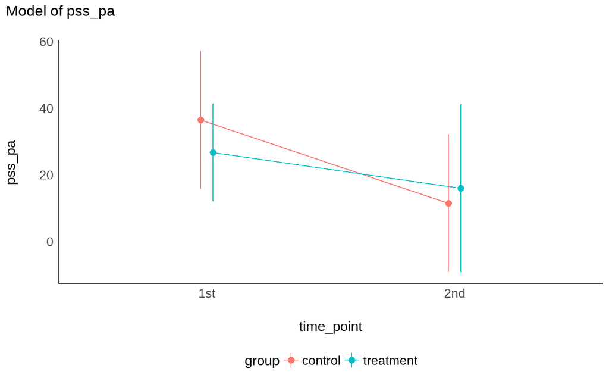

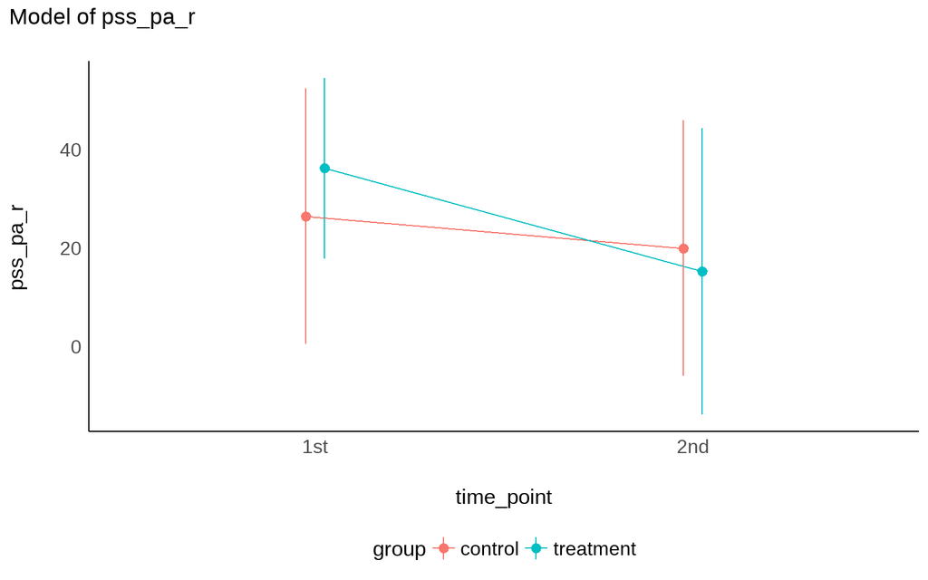

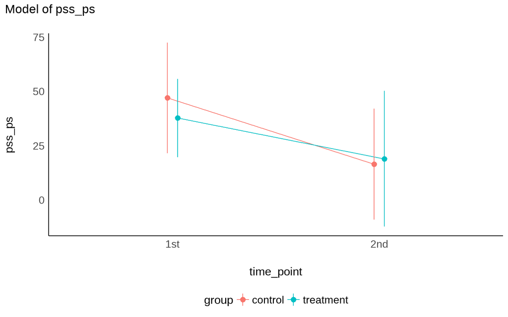

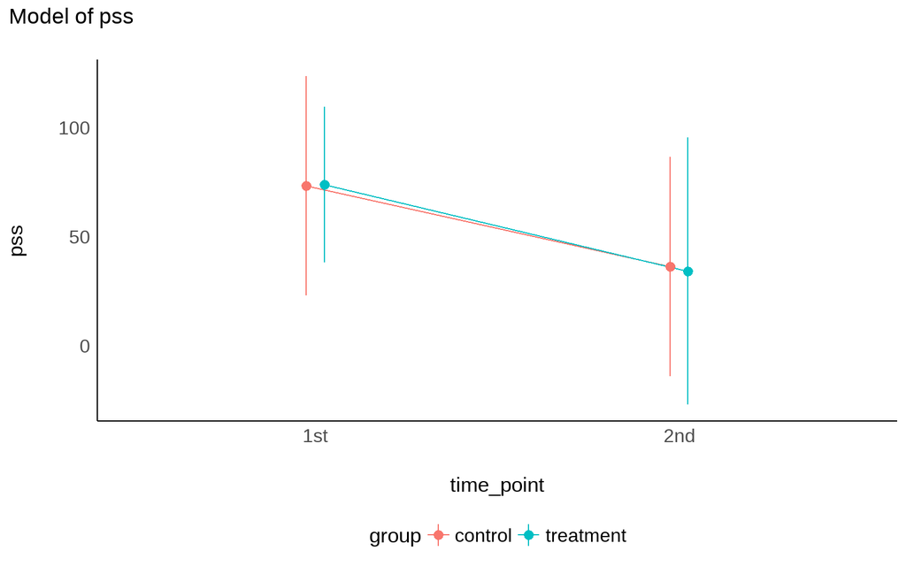

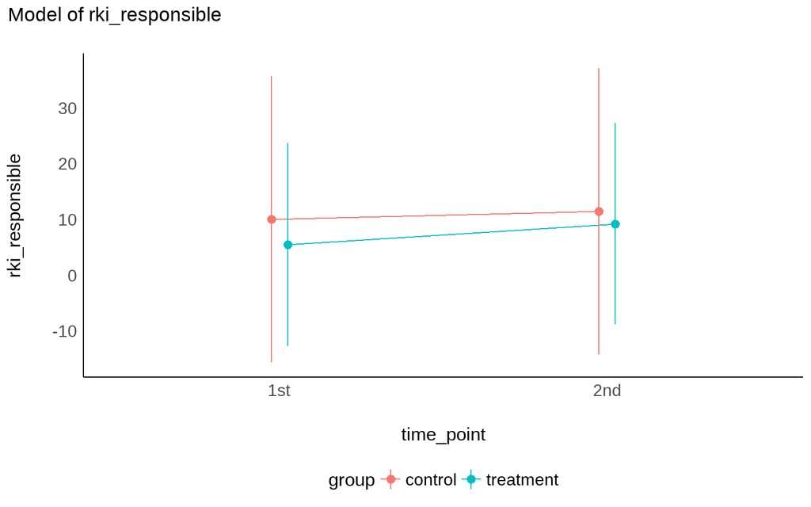

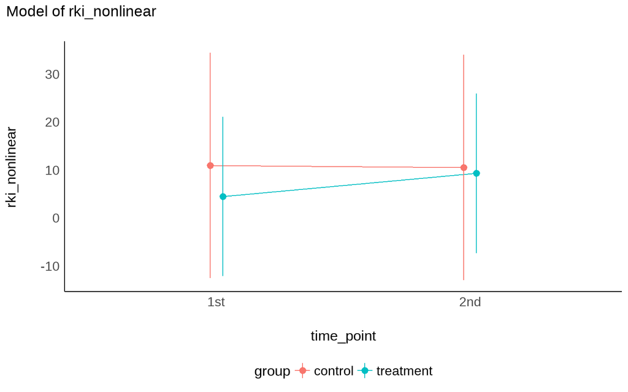

[8 more figures not shown]